# Cbind Result

#### Supplemental Figure 8

**Supplemental Figure 8 Functional characterization of the microbiome during the study**. A-B, the relative abundances of KEGG pathways(A) and modules(B) were compared between Baseline and Low calorie. C-D, the relative abundances of KEGG pathways(C) and modules(D) were compared between Low calorie and Washout. KEGG pathways or modules with reporter score > 1.65 or < - 1.65 are shown. Orange, Blue and red color represent BASE-, LOW- and WASH- enriched pathways or modules, respectively.

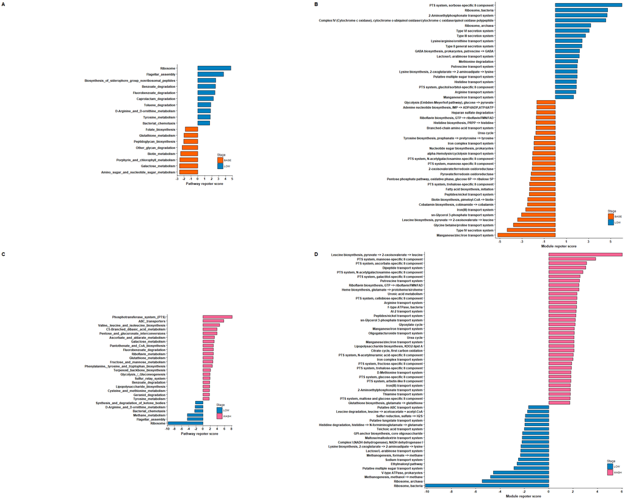

#### Supplemental Figure 9

**Supplemental Figure 9 KOs that are significantly altered (increased in red, depleted in green) in the gut microbiota of subjects after LCRD** for (A) 3 weeks (LOW) compared with baseline (BASE) and (B) after washout for 2 weeks (WASH) compared with LCRD (LOW) (Paired Wilcoxon signed–rank test; p<0.05). (C) different regulated KOs between LOW and WASH.

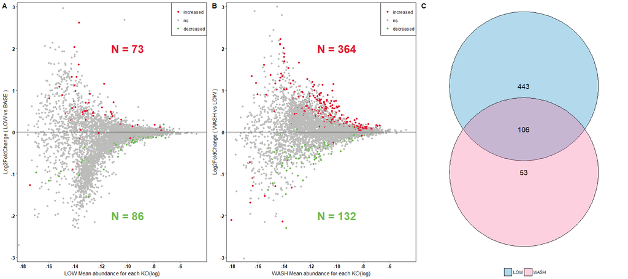